# Allocation of grid data to voting offices

Prelimlinary statistical explorations

Author

Claude Grasland

Published

November 9, 2026

## Objective

Linking electoral data and socio-economic data at the level of voting offices.

## (A) Geometric interesection

### Load map of voting offices

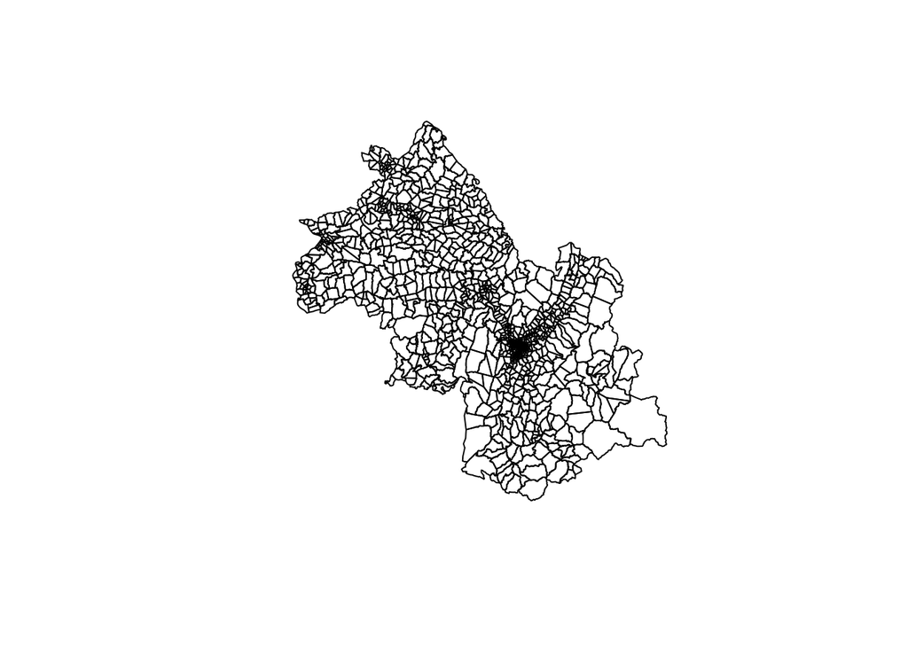

### Load centroid of grid

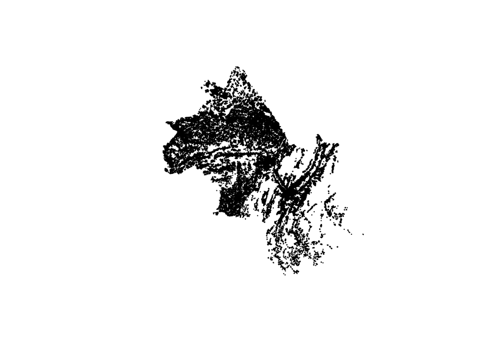

### Geometric intersection

We proceed to a geometric interesection of the two geometries in order to allocate each grid point to a voting office. Only a few seconds are necessary to achieve the task in the case of Isère (41768 grid points and 1070 voting offices)

## (B) Socio economic data

### raw count

We are now able to allocate socio economic data to voting offices. Let’s try to extract some raw count variable of interest

- ind = number of inhabitants
- men = number of households
- men_pauv = number of poor households
- men_mais = number of househoulds living in houses
- men_prop = number of housholds with property
- log_soc = number of households in social sector
- ind_snv = sun of incomes
- ind_18_24 = population aged 18-24
- ind_25_39 = population aged 25-39
- ind_40_54 = population aged 40-54
- ind_55_64 = population aged 55-64
- ind_65_79 = population aged 65-79
- ind_80p = population aged 80 and more

### Indicators

We can derive from this raw count variables some socio-economic and demographic indicators :

- txpauv = % of poor housholds
- txmais = % of households living in houses
- txprop = % of houshold with property
- txhlm = % of household in social housing
- revhab = estimated income per capita in €
- tx1824 = % of 18-24 in population aged 18 and more
- tx2539 = % of 25-39 in population aged 18 and more
- tx4054 = % of 40_54 in population aged 18 and more
- tx5564 = % of 55-64 in population aged 18 and more
- tx6579 = % of 65-79 in population aged 18 and more
- tx80p = % of 80+ in population aged 18 and more

### Linkage with electoral data

We merge the socio-economic data with electoral data of presidential election 2022 and save the resulting file.

## (C) Application I : Ecological analysis of abstention

Let’s consider the case of the abstention rate by voting office. We eliminate the case of voting office with less than 20 register or less than 50 inhabitants. We propose here to verify the correlation between the target variables and classical indicators used generally in survey at individual level. The idea here is to verify if the ecological analysis show the same conclusion despite the fact that we are not using individual informations.

### Income

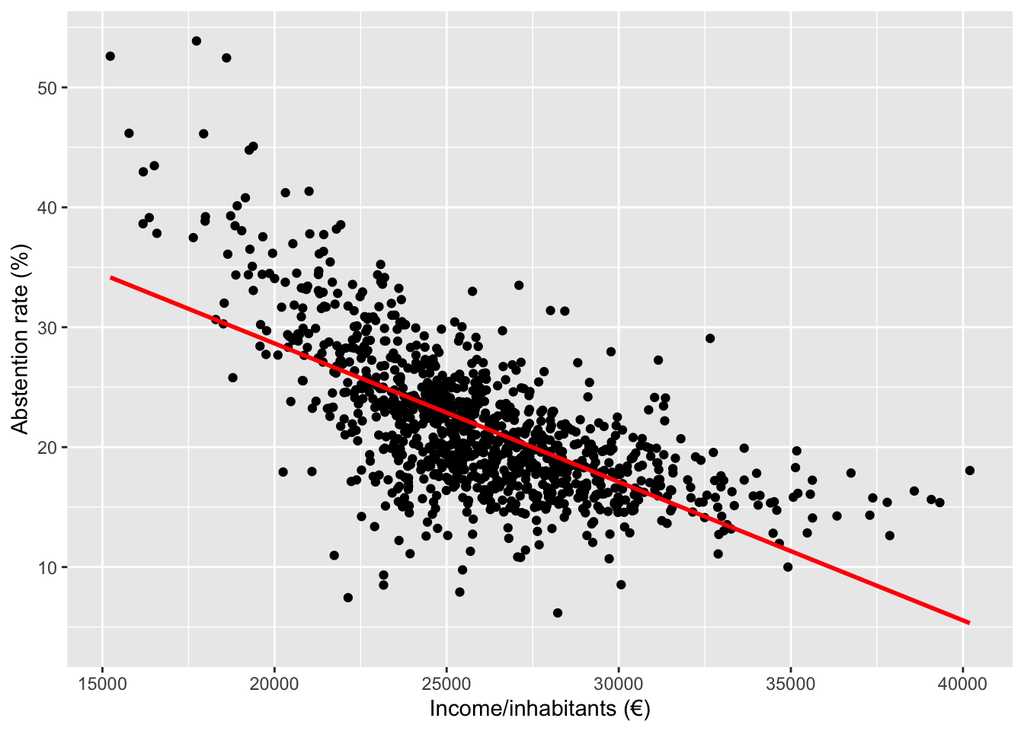

- **Comment** : The ecological analysis confirms the well-known result of a negative relation (non-linear) between abstention and income. The granularity of data is sufficient to conclude that the relation is probably not too much biased and would probably remain true at individual level.

### Property of house

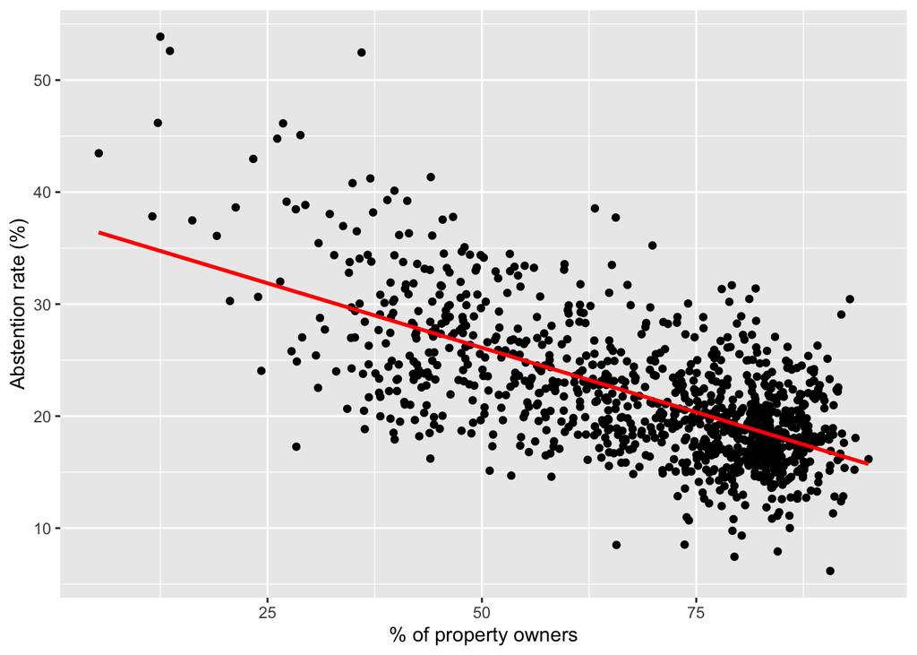

- **Comment** : The share of property owners is negatively correlated with abstention. Is it just an effect of income level ?

### Living in HLM (social sector)

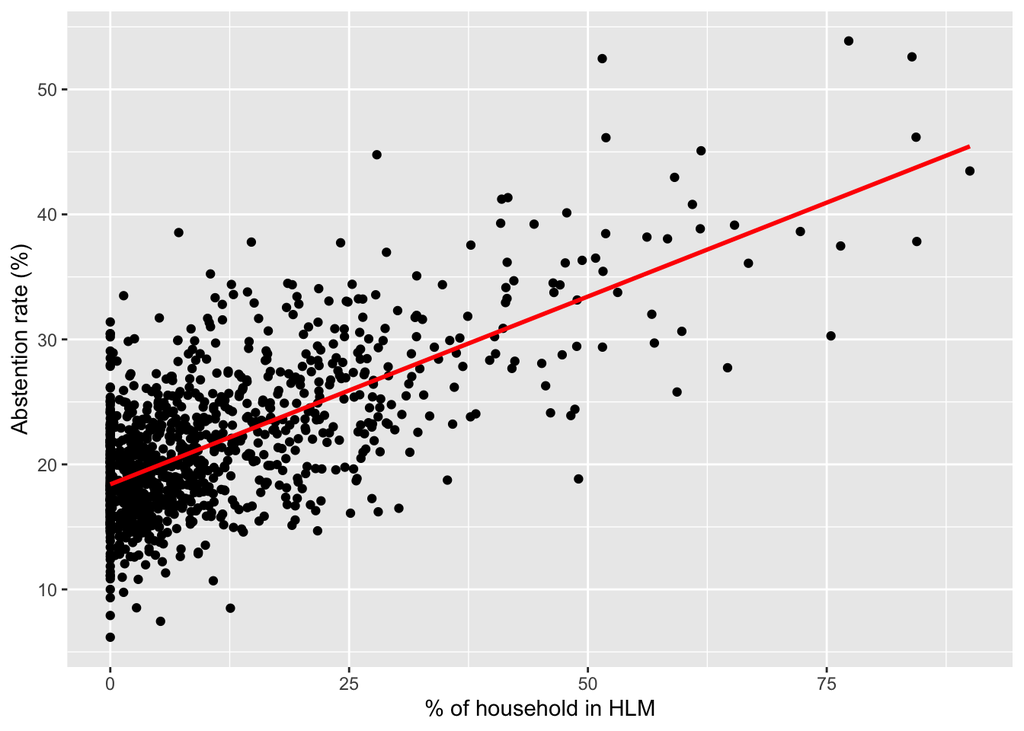

- **Comment** : The share of people living in HLM (social housing) is positively correlated with abstention which is a classical resultn to some extent related to income.

### Young elector (18-24 years old)

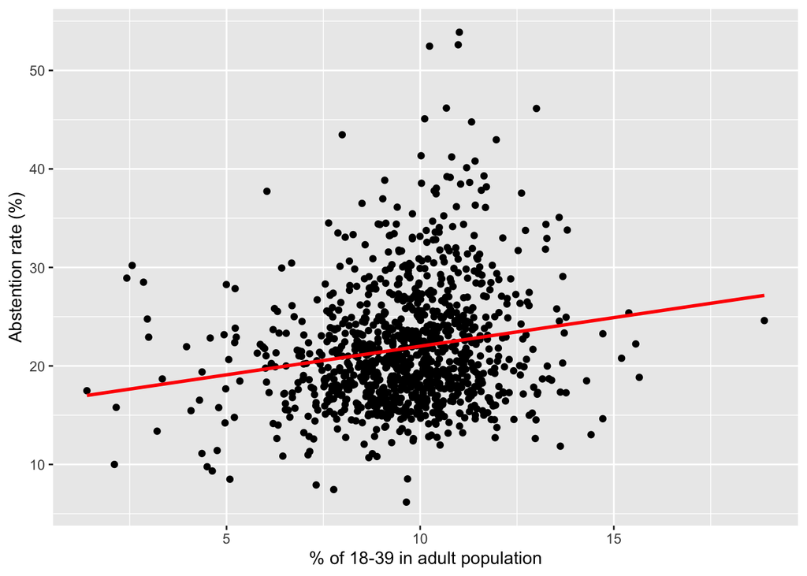

- **Comment** : The share of very young electors is positively correlated with abstention but the relation is rather low.

### Old electors (65 years old and more)

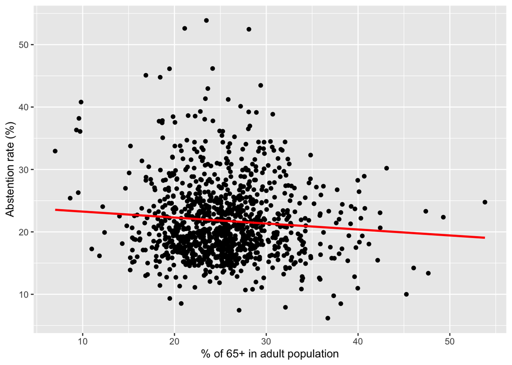

- **Comment** : The share of old electors is negatively correlated with abstention but the relation is rather low.

### Multiple regression

```
Call:
lm(formula = Y ~ revhab + txprop + txhlm + young + old, data = don)

Residuals:
     Min       1Q   Median       3Q      Max
-15.1483  -2.4409  -0.1715   2.3144  17.9315

Coefficients:
              Estimate Std. Error t value Pr(>|t|)
(Intercept)  3.855e+01  1.812e+00  21.278  < 2e-16 ***
revhab      -7.001e-04  4.559e-05 -15.359  < 2e-16 ***
txprop      -5.849e-02  1.270e-02  -4.605 4.62e-06 ***
txhlm        1.337e-01  1.547e-02   8.640  < 2e-16 ***
young        2.772e-01  8.032e-02   3.452 0.000579 ***
old          4.943e-02  2.530e-02   1.953 0.051048 .
---
Signif. codes:  0 '***' 0.001 '**' 0.01 '*' 0.05 '.' 0.1 ' ' 1

Residual standard error: 3.99 on 1048 degrees of freedom
Multiple R-squared:  0.5839,    Adjusted R-squared:  0.5819
F-statistic: 294.1 on 5 and 1048 DF,  p-value: < 2.2e-16
```

- **Comment** : The most significant explanaory variable is the average income of inhabitant. The fact to be owner of a property produce also a decrease of abstention when it is combined with other explanatory variables. Abstention is higher than expected for young electors and people living in HLM. Old people is the only variable that it is not really significant. But its effect is rather an increase of abstention, all things being equal.